# Homework 1

Author

Elisabeth Gangwer

Professional wrestling, while not everyone’s cup of tea, is big business. What started as a carnival act has turned into a global entertainment industry. Netflix recently started showing Monday Night Raw, a program from the biggest North American wrestling company, WWE – this deal is reportedly worth $5 billion. Like any large entity, WWE is not without competition, drama, and scandal.

## General Tips

This is very much a step-by-step process. Don’t go crazy trying to get everything done with as few lines as possible. Read the documentation for the AlphaVantage api! Carefully explore the pages from cagematch. There isn’t a need to get too fancy with anything here – just go with simple function and all should be good. Don’t print comments, but use normal text for explanations.

## Step 1

In the `calls` folder, you’ll find 4 text files – these are transcripts from quarterly earnings calls. Read those files in (glob.glob will be very helpful here), with appropriate column names for ticker, quarter, and year columns; this should be done within a single function. Perform any data cleaning that you find necessary.

```python
import glob as glob
import pandas as pd
import re

globs = glob.glob("/Users/elisabethgangwer/Desktop/unstructured/homework_1/calls/*.txt")

globs[0]
data = [ ]

for i in globs:
    table = pd.read_table(i, header = None)
    name = re.search(r'(?<=calls/).*', i).group().replace('.txt', '')

    table['ticker'] =re.search(r'(^[^_]+)', name).group()
    table['quarter'] = re.search(r'(?<=_q)\d', name).group()
    table['year'] = re.search(r'(?<=_q\d_)\d{4}', name).group()

    data.append(table)

df = pd.concat(data)
print(df)
```

```
                                                     0 ticker quarter  year
0                                 Company Participants    wwe       1  2023
1                             Seth Zaslow - Head of IR    wwe       1  2023
2                                      Nick Khan - CEO    wwe       1  2023
3                                  Frank Riddick - CFO    wwe       1  2023
4                Paul Levesque - Chief Content Officer    wwe       1  2023
..                                                 ...    ...     ...   ...
134  So in reverse order, ad share deal with Twitch...    wwe       2  2023
135                                        Seth Zaslow    wwe       2  2023
136  Well, thank you, everyone, for joining us on t...    wwe       2  2023
137                                           Operator    wwe       2  2023
138  This concludes today's call. Thank you again f...    wwe       2  2023

[705 rows x 4 columns]
```

## Step 2

Use the AlphaVantage api to get daily stock prices for WWE and related tickers for the last 5 years – pay attention to your data. You cannot use any AlphaVantage packages (i.e., you can only use requests to grab the data). Tell me about the general trend that you are seeing. I don’t care which viz package you use, but plotly is solid and plotnine is good for ggplot2 users.

```python
import requests
import json
import pandas as pd

def grab(symbol):
  av_k = "37C54FKKP09DIP13"
  av_symbol = f"{symbol}"
  av_link = f"https://www.alphavantage.co/query?function=TIME_SERIES_DAILY&symbol={av_symbol}&outputsize=full&apikey={av_k}"
  av_request = requests.get(av_link)
  av_json = av_request.json()
  series_data = av_json['Time Series (Daily)']
  meta_data = av_json['Meta Data']
  av_data = pd.DataFrame.from_dict(series_data, orient='index')
  av_data['symbol'] = meta_data['2. Symbol']
  av_data.reset_index(inplace = True)
  av_data = av_data.rename(columns = {'index':'date'})
  av_data['date'] = pd.to_datetime(av_data['date'])
  av_data['close'] = pd.to_numeric(av_data['4. close'])

  return av_data


edr = grab('EDR')
wwe = grab('WWE')
tko = grab('TKO')

print(edr, wwe, tko)
```

```
          date  1. open  2. high   3. low 4. close 5. volume symbol  close
0   2025-02-05  31.0400  31.2700  30.4700  30.8600    465962    EDR  30.86
1   2025-02-04  30.5700  31.1500  30.4300  30.9000    479408    EDR  30.90
2   2025-02-03  29.5600  30.5000  29.5600  30.4400    686223    EDR  30.44
3   2025-01-31  32.2200  32.6700  29.6100  30.5800   1257571    EDR  30.58
4   2025-01-30  30.9500  31.3400  30.4400  31.0100   1034038    EDR  31.01
..         ...      ...      ...      ...      ...       ...    ...    ...
944 2021-05-04  29.8000  32.5800  28.5000  29.9900   3344592    EDR  29.99
945 2021-05-03  29.3400  32.4500  28.0500  30.8100   7950467    EDR  30.81
946 2021-04-30  25.1500  28.7599  25.0000  27.5600   8878696    EDR  27.56
947 2021-04-29  27.0000  28.4700  23.2500  25.2000  15962510    EDR  25.20
948 2021-04-28  24.0000  24.0000  24.0000  24.0000       100    EDR  24.00

[949 rows x 8 columns]            date   1. open   2. high   3. low  4. close 5. volume symbol  \
0    2023-09-11   99.5100  101.9400  98.0700  100.6500   1642135    WWE
```

[output cut: 51 more lines]

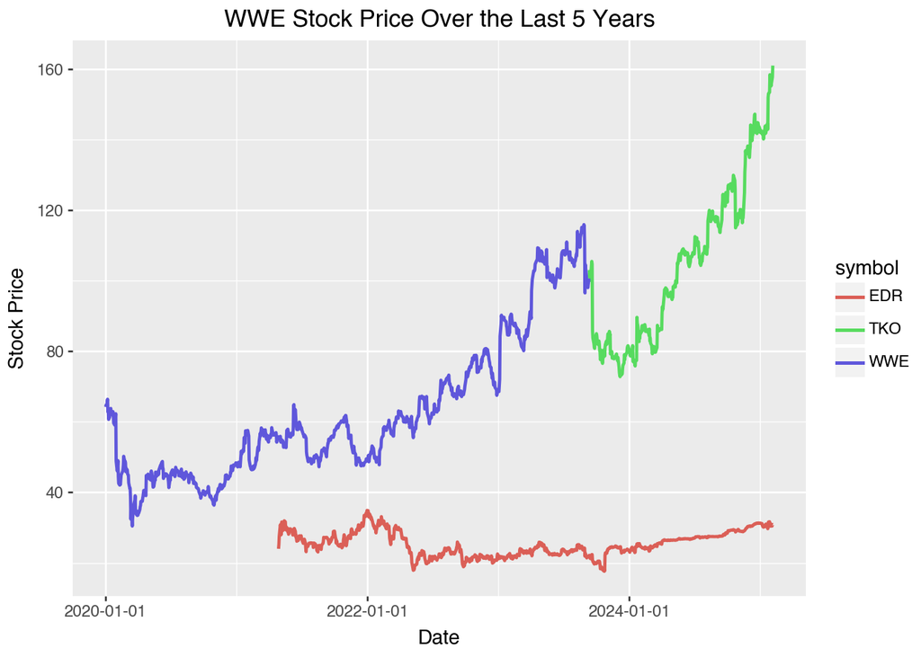

```python
from plotnine import *
import pandas as pd

all_stock = pd.concat([edr, wwe, tko])
all_stock = all_stock.loc[all_stock['date'] > '2020-01-01']

ggplot(all_stock, aes(x="date", y="close", color = "symbol")) + geom_line( size=1) + labs(title="WWE Stock Price Over the Last 5 Years", x="Date", y="Stock Price")
```

TKO/WWE stock prices have been increasing with a slight dip at the end of 2023 and beginning of 2024 when WWE merged with TKO. TKO stock prices are now continuing to rise, with its higherst stock prices in the past 5 Years. EDR stock prices seem to be mostly stable with slight dips over the past 2 years.

## Step 3

Just like every other nerdy hobby, professional wrestling draws dedicated fans. Wrestling fans often go to cagematch.net to leave reviews for matches, shows, and wrestlers. The following link contains the top 100 matches on cagematch: https://www.cagematch.net/?id=111&view=statistics

- What is the correlation between WON ratings and cagematch ratings?

** Which wrestler has the most matches in the top 100?

*** Which promotion has the most matches in the top 100?

**** What is each promotion’s average WON rating?

***** Select any single match and get the comments and ratings for that match into a data frame.

```python
from bs4 import BeautifulSoup
import numpy as np
import pandas as pd
import re
import requests
import time
```

```python
link = ("https://www.cagematch.net/?id=111&view=statistics")
cagematch = requests.get(link)
cagematch_soup = BeautifulSoup(cagematch.content, "html.parser")

row1 = cagematch_soup.select('.TRow1')
row2 = cagematch_soup.select('.TRow2')
row_range = range(0, len(row1))


row1_promotion = cagematch_soup.select(".TRow1 .ImagePromotionLogoMini")
row2_promotion = cagematch_soup.select(".TRow2 .ImagePromotionLogoMini")
row1_promo = [row1_promotion[x].get('title') for x in row_range]
row2_promo = [row2_promotion[x].get('title') for x in row_range]


row1_data = [ ]
for i in row1:
  cols = i.select('td')
  data = {
    'rank': cols[0].text.strip(),
    'date': cols[1].text.strip(),
    'match': cols[3].text.strip(),
    'WON rating': cols[4].text.strip(),
    'match type': cols[5].text.strip(),
    'rating': cols[6].text.strip(),
    'votes': cols[7].text.strip()
  }
  row1_data.append(data)


row2_data = [ ]
for i in row2:
  cols = i.select('td')
  data = {
    'rank': cols[0].text.strip(),
    'date': cols[1].text.strip(),
    'match': cols[3].text.strip(),
    'WON rating': cols[4].text.strip(),
    'match type': cols[5].text.strip(),
    'rating': cols[6].text.strip(),
    'votes': cols[7].text.strip()
  }
  row2_data.append(data)


row1_df = pd.DataFrame(row1_data)
row2_df = pd.DataFrame(row2_data)
row1_df['promotion'] = row1_promo
row2_df['promotion'] = row2_promo

df = pd.concat([row1_df, row2_df])
print(df)
```

```
   rank        date                                              match  \
0     1  04.01.2017                    Kazuchika Okada vs. Kenny Omega
1     3  09.04.2017              Katsuyori Shibata vs. Kazuchika Okada
2     5  09.06.2018                    Kazuchika Okada vs. Kenny Omega
3     7  12.08.2018                  Hiroshi Tanahashi vs. Kota Ibushi
4     9  13.08.2016                      Kenny Omega vs. Tetsuya Naito
..  ...         ...                                                ...
45   92  02.04.1989                      Ric Flair vs. Ricky Steamboat
46   94  06.08.2016                 Kazuchika Okada vs. Tomohiro Ishii
47   96  15.07.2023  Cash Wheeler & Dax Harwood vs. Jay White & Jui...
48   98  31.03.2006  CIMA, Masato Yoshino & Naruki Doi vs. Dragon K...
49  100  04.01.2019                  Hiroshi Tanahashi vs. Kenny Omega

   WON rating                            match type rating votes  \
0      ******                               Singles   9.81  1317
```

[output cut: 25 more lines]

```python
# Correlation between WON rating and Cagematch rating
from plotnine import *

df['rank'] = pd.to_numeric(df['rank'])
df['rating'] = pd.to_numeric(df['rating'])


df['WON_numeric'] = df['WON rating'].apply(lambda star_string:
  star_string.count('*') +
  (0.25 if '1/4' in star_string else
  0.5 if '1/2' in star_string else
  0.75 if '3/4' in star_string else 0))

df['WON_numeric'] = df['WON_numeric'].replace(0, np.nan)

WON_rating_corr = df['WON_numeric'].corr(df['rating'])

print(f"The correlation between WON rating and Cagematch rating is: {round(WON_rating_corr, 2)}")
```

```
The correlation between WON rating and Cagematch rating is: 0.31
```

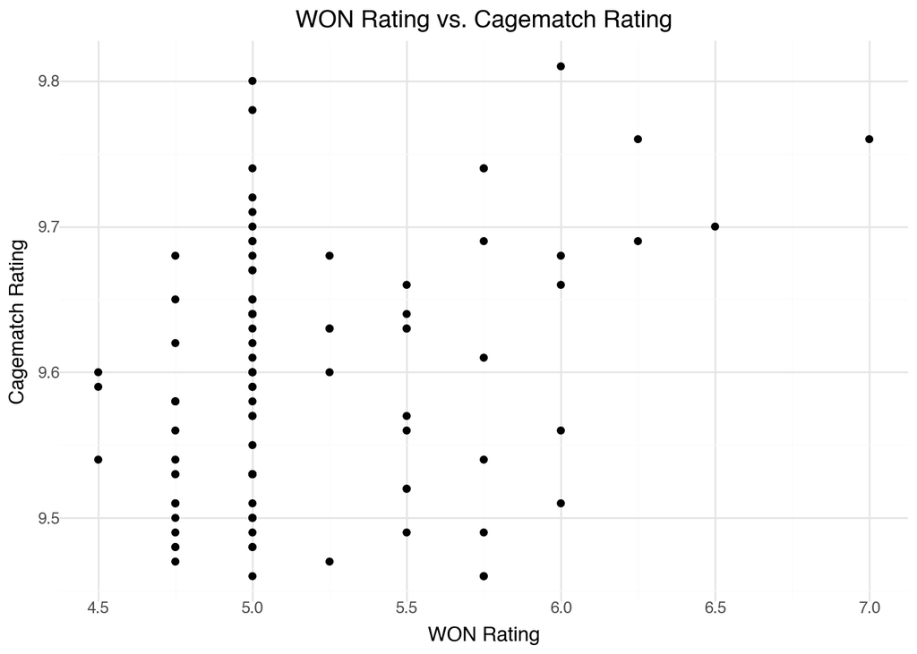

```python
ggplot(df, aes(x='WON_numeric', y='rating')) + geom_point() + labs(title="WON Rating vs. Cagematch Rating", x="WON Rating", y="Cagematch Rating") + theme_minimal()
```

```python
# Wrestler with the most matches in the top 100
df['match'] = df['match'].astype(str)
match_list = [ ]

for i in df['match']:
  match = re.split(r' vs\. |, | & ', i)
  match_list.append(match)

df['wrestler_list'] = match_list
matchup_count = df['wrestler_list'].explode().value_counts()

print(f"The wrestler with the most matches in the top 100 is: {matchup_count.idxmax()} with {matchup_count.max()} matches.")
```

```
The wrestler with the most matches in the top 100 is: Kenny Omega with 16 matches.
```

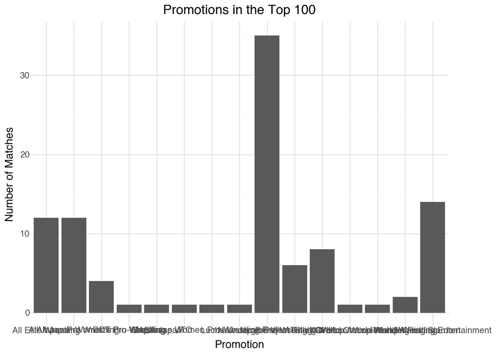

```python
# Promotion with the most matches in the top 100
promotion_count = df['promotion'].value_counts()
ggplot(df, aes(x='promotion')) + geom_bar() + labs(title="Promotions in the Top 100", x="Promotion", y="Number of Matches") + theme_minimal()
```

```python
promotion_top = promotion_count.idxmax()
print(f"The promotion that has the most matches in the top 100 is: {promotion_top} with {promotion_count.max()} matches.")
```

```
The promotion that has the most matches in the top 100 is: New Japan Pro Wrestling with 35 matches.
```

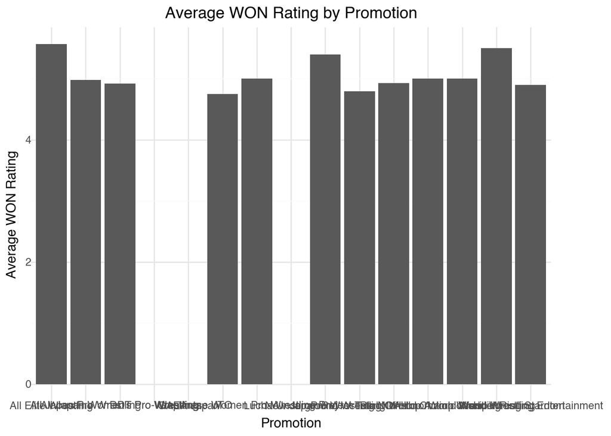

```python
# Promotion Average by WON Rating
promotion_avg = df.groupby('promotion')['WON_numeric'].mean().reset_index()
ggplot(promotion_avg, aes(x='promotion', y='WON_numeric')) + geom_bar(stat='identity') + labs(title="Average WON Rating by Promotion", x="Promotion", y="Average WON Rating") + theme_minimal()
```

```python
print(promotion_avg)
```

```
                               promotion  WON_numeric
0                    All Elite Wrestling     5.562500
1                All Japan Pro Wrestling     4.979167
2        All Japan Women's Pro-Wrestling     4.916667
3                      DDT Pro Wrestling          NaN
4                             GAEA Japan          NaN
5                                    JTO     4.750000
6   Japanese Women Pro-Wrestling Project     5.000000
7                      Lucha Underground          NaN
8                New Japan Pro Wrestling     5.392857
9                     Pro Wrestling NOAH     4.791667
10                         Ring Of Honor     4.928571
11        Total Nonstop Action Wrestling     5.000000
12          World Championship Wrestling     5.000000
13             World Wonder Ring Stardom     5.500000
14         World Wrestling Entertainment     4.892857
```

```python
# Single Match Comments and Ratings

def grab(page):
  page_num = f"{page}"
  link = f"https://www.cagematch.net/?id=111&nr=64677&page=98&s={page_num}"
  single_match = requests.get(link)
  single_soup = BeautifulSoup(single_match.content, "html.parser")
  content = single_soup.select('tr')[1: ]
  return content

page = [0, 100, 200, 300, 400, 500]

comment_data = [ ]
for x in page:
  comments = grab(x)
  for i in comments:
    cols = i.select('td')
    data = {
      'review_number': cols[0].text.strip(),
      'date_reviewed': cols[1].text.strip(),
      'user': cols[2].text.strip(),
      'rating': cols[3].text.strip(),
      'comment': cols[4].text.strip()
    }
    comment_data.append(data)

review_comments = pd.DataFrame(comment_data)
print(review_comments)
```

```
    review_number date_reviewed          user rating  \
0               1    04.02.2025  LariatOfFire    9.0
1               2    04.02.2025  Scarletsound    9.0
2               3    04.02.2025    penta dark
3               4    15.01.2025       JackM99   10.0
4               5    06.01.2025    KurtMack13   10.0
..            ...           ...           ...    ...
591           592    11.12.2022      marexcel    9.0
592           593    11.12.2022  cooksthegoat   10.0
593           594    11.12.2022      Hazelyze   10.0
594           595    11.12.2022     li0nsault    9.0
595           596    11.12.2022  SimonMatveev   10.0

                                               comment
0
1
2    This match is the perfect ending to, in my opi...
3
4
..                                                 ...
591
592
593  And thus caps off the best tag team rivalry I'...
594  I don't think it was the best match of their r...
595  This is simply one of the best tag team matche...

[596 rows x 5 columns]
```

## Step 4

You can’t have matches without wrestlers. The following link contains the top 100 wrestlers, according to cagematch: https://www.cagematch.net/?id=2&view=statistics

*** Of the top 100, who has wrestled the most matches?

***** Of the top 100, which wrestler has the best win/loss?

```python
from bs4 import BeautifulSoup
import pandas as pd
import re
import requests


link = ("https://www.cagematch.net/?id=2&view=statistics")
wrestler = requests.get(link)
wrestler_soup = BeautifulSoup(wrestler.content, "html.parser")

top100_links = wrestler_soup.select('a[href*="?id=2&nr"]')
top100_links = re.sub('amp;', '', str(top100_links))
top100_links = re.findall(r'(?<=href=").*?(?=")', (top100_links))

id_nr = re.findall(r'(?<=nr=)\d*', str(top100_links))

def wrestler_stats(page):
  page_num = f"{page}"
  wrestler_link = f"https://www.cagematch.net/?id=2&nr={page_num}&page=22"
  stats = requests.get(wrestler_link)
  stats_soup = BeautifulSoup(stats.content, "html.parser")
  content = stats_soup.select('.InformationBoxContents')
  return content

stats_data = [ ]
for x in id_nr:
  stats_content = wrestler_stats(x)
  data = {
    'match_count': stats_content[0].text.strip(),
    'wins': stats_content[1].text.strip(),
    'loss': stats_content[2].text.strip(),
    'draw': stats_content[3].text.strip()
  }
  stats_data.append(data)

empty_data = [ ]
for i in stats_data:
  i['match_count'] = re.search(r'\d+', i['match_count']).group()
  i['wins'] = re.search(r'\d+', i['wins']).group()
  i['loss'] = re.search(r'\d+', i['loss']).group()
  i['draw'] = re.search(r'\d+', i['draw']).group()
  empty_data.append(i)

stats_df = pd.DataFrame(empty_data)
stats_df[['match_count', 'wins', 'loss', 'draw']] = stats_df[['match_count', 'wins', 'loss', 'draw']].apply(pd.to_numeric)
stats_df['win_perc'] = round((stats_df['wins'] / stats_df['match_count']) * 100, 2)
stats_df['loss_perc'] = round((stats_df['loss'] / stats_df['match_count']) * 100, 2)
stats_df['draw_perc'] = round((stats_df['draw'] / stats_df['match_count']) * 100, 2)
stats_df['win_loss_ratio'] = round(stats_df['wins'] / stats_df['loss'], 2)


wrestler_names = wrestler_soup.select('tr')[1:]
wrestler_names_data = [ ]

for i in wrestler_names:
  cols = i.select('td')
  data = {
    'rank': cols[0].text.strip(),
    'wrestler': cols[1].text.strip(),
  }
  wrestler_names_data.append(data)
wrestler_names_df = pd.DataFrame(wrestler_names_data)


complete_df = pd.concat([wrestler_names_df, stats_df], axis=1)
complete_df['win_loss_ratio'].replace(np.inf, np.nan, inplace=True)

print(complete_df)

print(f"The wrestler with the most matches is: {complete_df['wrestler'][complete_df['match_count'].idxmax()]} with {complete_df['match_count'].max()} matches.")

print(f"The wrestler with the best win/loss ratio is: {complete_df['wrestler'][complete_df['win_loss_ratio'].idxmax()]} with a win/loss ratio of {complete_df['win_loss_ratio'].max()}.")
```

```
   rank          wrestler  match_count  wins  loss  draw  win_perc  loss_perc  \
0     1     Kenta Kobashi         2405  1195  1152    58     49.69      47.90
1     2  Mitsuharu Misawa         3557  1937  1441   179     54.46      40.51
2     3   Toshiaki Kawada         3043  1477  1398   168     48.54      45.94
3     4      Mayu Iwatani         1022   494   460    68     48.34      45.01
4     5     Manami Toyota         2740  1616  1009   115     58.98      36.82
..  ...               ...          ...   ...   ...   ...       ...        ...
95   96         Ric Flair         4999  2553  1971   475     51.07      39.43
96   97      Great Sasuke         2088  1193   830    65     57.14      39.75
97   98       Suzu Suzuki          699   357   284    58     51.07      40.63
98   99            Sareee          746   320   367    59     42.90      49.20
99  100        Chris Hero         1825   913   867    45     50.03      47.51

    draw_perc  win_loss_ratio
0        2.41            1.04
1        5.03            1.34
2        5.52            1.06
3        6.65            1.07
4        4.20            1.60
..        ...             ...
95       9.50            1.30
96       3.11            1.44
97       8.30            1.26
98       7.91            0.87
99       2.47            1.05

[100 rows x 10 columns]
The wrestler with the most matches is: Ric Flair with 4999 matches.
The wrestler with the best win/loss ratio is: Lou Thesz with a win/loss ratio of 9.45.
```

## Step 5

With all of this work out of the way, we can start getting down to strategy.

First, what talent should WWE pursue? Advise carefully.

Considering that WWE is in the Top100 Matches on cagematch 14 times, WWE has a relatively average WON rating score of 4.89. It could be beneficial for WWE to pursue wrestlers from different promotions like All Elite Wrestling, New Japan Pro-Wrestling, or All Japan Pro Wrestling, which have higher average WON ratings. Bringing in diverse talent would not only create fresh and exciting matchups but also help WWE reach a more global audience.

Second, reconcile what you found in steps 3 and 4 with Netflix’s relationship with WWE. Use the data from the following page to help make your case: https://wrestlenomics.com/tv-ratings/

Although WWE has a strong fan base, its viewership has devlinded over the past year. WWE’s stock prices have been slowly increasing, with a slight dip in 2024 when WWE merged with TKO. However, after Netflix and WWE announced their partnership in January 2024, WWE’s stock prices began to rise again. Showing their partnership with Netflix has had a positive market response. In addition, WWE’s new partnership with Netflix has the potential to significantly impact its viewership. With the rise in popularity of streaming services and Netflix being one of the most widely used streaming service, WWE can reach a broader and more diverse audience. Potentially allowing for an increase in WWE’s viewership and stock prices.

Third, do you have any further recommendations for WWE?

If WWE and Netflix’s partnership continues to grow, WWE should consider moving more of its content to Netflix.Expanding its presence on Netflix could further increase viewership and engagement, especially among younger audiences who primarily consume content online. Another suggestion is to create nostalgic content by feauting iconic wrestlers or recreating legendary matchups. This could appeal to long-time fans, attract older viewers while keeping the interest of new viewers. Overall, WWE has the potential to strengthen its brand and increase its viewership by leveraging its partnership with Netflix and creating engaging content that resonates with a wide audience.